# Transcriptomics

Hugo Pineda, Joeri Jongbloets

March 05 2020

# 1 Preparation

In the `load_data` chunk we have loaded all the data we will need for the analysis. We have 3 data.frames:

- `df.counts.raw`: contains the counts for each gene an sample.
- `df.submission`: contains information about the RNA-extraction samples.
- `df.design`: maps sample_ids to the conditions of the experiment.

## 1.1 Matching RNA-seq samples to conditions

In the `df.counts.raw` data.frame, samples are identified by the `sequence_id` column:

| sequence_id |
| --- |
| S01 |
| S02 |
| S03 |
| S04 |
| S05 |
| S06 |

In order to map `sequence_id` to `sample_id` we to combine the information in `df.submission` and `df.design`:

Submission file.

| isolation_date | sample_id | sequence_id | volume_ul | conc_ng_ul | A260 | ratio_260_230 | ratio_260_280 | yield_ug |
| --- | --- | --- | --- | --- | --- | --- | --- | --- |
| 2020-01-19 | 191226_PC_2_1 | S01 | 59 | 63.202 | 1.5800 | 1.985 | 2.061 | 3.728918 |
| 2020-01-19 | 191226_PC_2_3 | S02 | 59 | 118.006 | 2.9502 | 1.454 | 2.224 | 6.962354 |
| 2020-01-19 | 191226_PC_2_4 | S03 | 59 | 29.625 | 0.7400 | 1.305 | 2.095 | 1.747875 |
| 2020-01-19 | 200116_PC_3_1 | S04 | 59 | 94.049 | 2.3512 | 2.197 | 2.233 | 5.548891 |
| 2020-01-19 | 200116_PC_3_3 | S05 | 59 | 169.249 | 4.2312 | 2.255 | 2.153 | 9.985691 |
| 2020-01-19 | 200116_PC_3_4 | S06 | 59 | 73.703 | 1.8426 | 2.185 | 2.108 | 4.348477 |

Design file.

| multicultivator | channel | strain | sample_time | sample_id | phosphate_mM | purpose | dataset |
| --- | --- | --- | --- | --- | --- | --- | --- |
| 0 | 1 | WT | NA | 191104_PC_1_1 | 0.2300 | control | pre-coure |
| 0 | 1 | WT | NA | 191226_PC_2_1 | 0.0115 | treatment | pre-coure |
| 0 | 1 | WT | NA | 200116_PC_3_1 | 0.2300 | control | pre-coure |
| 0 | 2 | WT | NA | 191104_PC_1_2 | 0.2300 | control | pre-coure |
| 0 | 3 | WT | NA | 191104_PC_1_3 | 0.2300 | control | pre-coure |
| 0 | 3 | WT | NA | 191226_PC_2_3 | 0.0115 | treatment | pre-coure |

Create a data.frame called `df.transcriptomics.design` combining the required information:

| sample_id | sequence_id | multicultivator | channel | strain | sample_time | phosphate_mM | purpose | dataset |
| --- | --- | --- | --- | --- | --- | --- | --- | --- |
| 191226_PC_2_1 | S01 | 0 | 1 | WT | NA | 0.0115 | treatment | pre-coure |
| 191226_PC_2_3 | S02 | 0 | 3 | WT | NA | 0.0115 | treatment | pre-coure |
| 191226_PC_2_4 | S03 | 0 | 4 | WT | NA | 0.0115 | treatment | pre-coure |
| 200116_PC_3_1 | S04 | 0 | 1 | WT | NA | 0.2300 | control | pre-coure |
| 200116_PC_3_3 | S05 | 0 | 3 | WT | NA | 0.2300 | control | pre-coure |
| 200116_PC_3_4 | S06 | 0 | 4 | WT | NA | 0.2300 | control | pre-coure |

# 2 Inspecting Feature Assignment

As mentioned above, the `df.counts.raw` data.frame contains the counts for each gene an sample. In addition, it contains some rows indicating the number of reads that were not aligned, ambiguous and for which no feature was found. This information is stored in the last rows of each counts file.

| gene | counts | sequence_id |
| --- | --- | --- |
| __no_feature | 666901 | S01 |
| __ambiguous | 192804 | S01 |
| __too_low_aQual | 0 | S01 |
| __not_aligned | 256021 | S01 |
| __alignment_not_unique | 0 | S01 |
| __no_feature | 1167785 | S02 |
| __ambiguous | 382194 | S02 |
| __too_low_aQual | 0 | S02 |
| __not_aligned | 352425 | S02 |
| __alignment_not_unique | 0 | S02 |
| __no_feature | 819476 | S03 |
| __ambiguous | 270242 | S03 |
| __too_low_aQual | 0 | S03 |
| __not_aligned | 212572 | S03 |
| __alignment_not_unique | 0 | S03 |
| __no_feature | 915897 | S04 |
| __ambiguous | 294485 | S04 |
| __too_low_aQual | 0 | S04 |
| __not_aligned | 287451 | S04 |
| __alignment_not_unique | 0 | S04 |
| __no_feature | 829787 | S05 |
| __ambiguous | 286712 | S05 |
| __too_low_aQual | 0 | S05 |
| __not_aligned | 372251 | S05 |
| __alignment_not_unique | 0 | S05 |
| __no_feature | 769118 | S06 |
| __ambiguous | 255793 | S06 |
| __too_low_aQual | 0 | S06 |
| __not_aligned | 285180 | S06 |
| __alignment_not_unique | 0 | S06 |

## 2.1 Exercise:

We want to have information about the alignment process. For each sample, make a plot showing the percentage of reads that were not aligned, ambiguous and for which no feature was found.

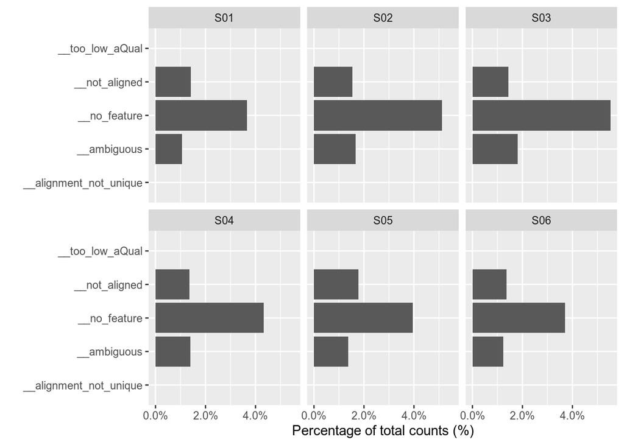

## 2.2 Exercise:

For further analyses, we will need a data.frame that do NOT contain these rows. Create such data.frame and name it `df.counts`.

# 3 Inspecting Raw Count Data

The goal of this exercise is to perform a quality control of the count data. In order to do this you will visualize the data using different types of plots.

## 3.1 Total number of counts

The total number of counts for each sample might be different due to multiple factors.

### 3.1.1 Exercise:

Create a barplot showing the total number of counts for each sample.

How many reads do you (approximately) have from each sample? Are the samples different? Do you see outliers? Can you conclude that the values are consistent, or is a normalization step required?

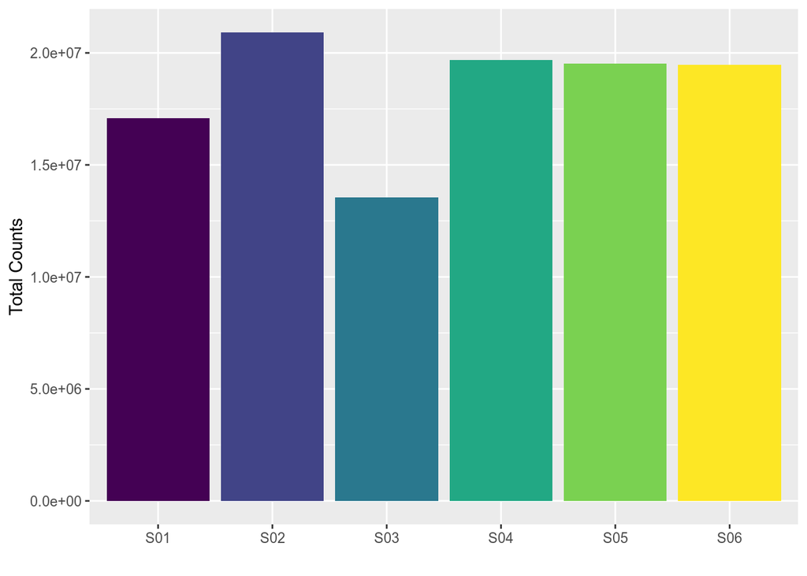

## 3.2 Ribosomal RNA

Out of all the RNA present in a prokaryotic cell, roughly 85% is ribosomal (r)RNAs. Thus when sequencing RNA 85% of the reads will be on non-coding rRNA, while we are interested in mRNA. To improve sensitivity and dynamic range on the mRNA levels we remove the rRNA, called ribosomal RNA depletion. We should check if this procedure was effective.

### 3.2.1 Exercise:

Create a barplot showing the percentage of counts for each rRNA to the total number of counts.

What percentage of the reads is mapped to rRNA? Has each sample roughly the same amount of rRNA reads? What would be the effect of deviations in rRNA level when we compare the samples? Should we correct the data somehow for this?

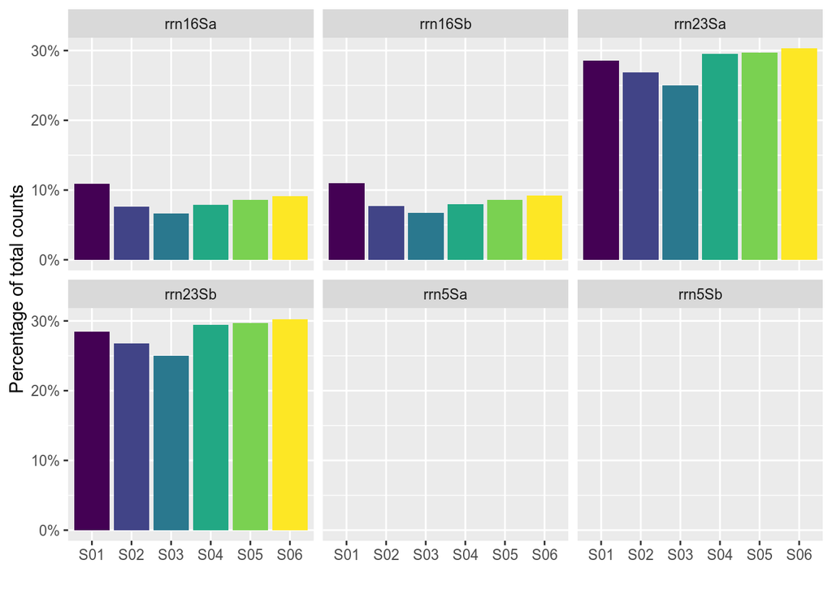

## 3.3 Filtering out low-count genes and rRNA

Researchers often filter out the genes that are measured with a very little amount of reads. These measurements are then considered unreliable.

### 3.3.1 Exercise:

Create a new data.frame called `df.counts.f` in which you filter out all rRNA genes and all the genes that are measured with less than 24 reads in all samples. In addition, create a new column named `counts_log2` that contains the counts in log space. We will need this column in the coming steps.

Hint: to avoid getting infinite values for genes with 0 counts, add 1 to all counts before you calculate the log. This is usually referred as pseudo-counts.

### 3.3.2 Exercise:

Did the filtering step have an impact on your data? Re-create the figure made in Excercise 2.1.1

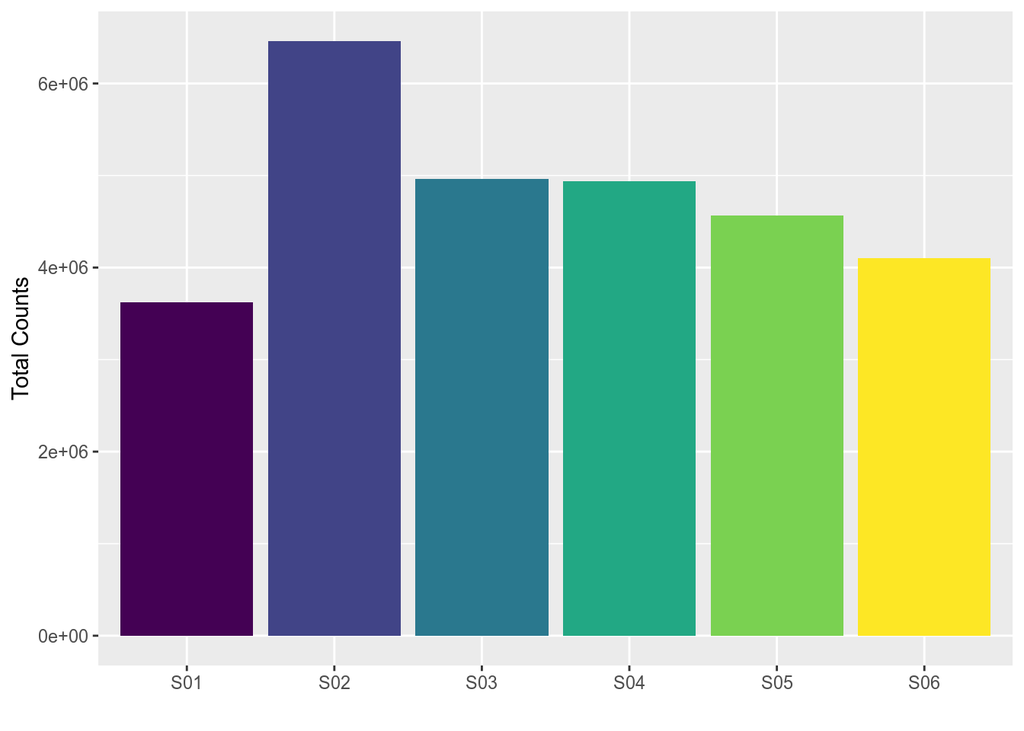

## 3.4 Visualizing counts’ distribution:

Another way to check if data needs to be normalized is to visualize the distribution of the counts. This is usually done in log space.

### 3.4.1 Excercise:

Make a boxplot to visualize the distribution in gene expression level, for every sample.

Are the samples similar or different? Do you see outliers? Can you conclude that the values are consistent, or is a normalization step required?

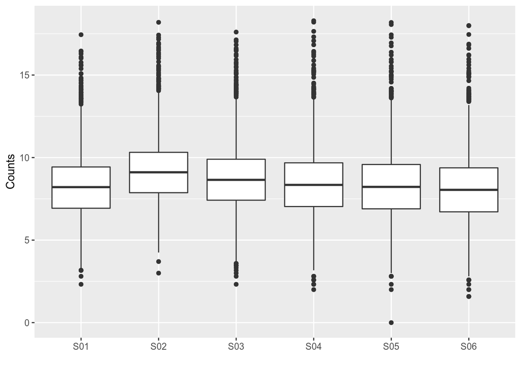

### 3.4.2 Excercise:

Make a density plot to visualize the distribution in gene expression level, for every sample.

Are the samples similar or different? Do you see outliers? Can you conclude that the values are consistent, or is a normalization step required?

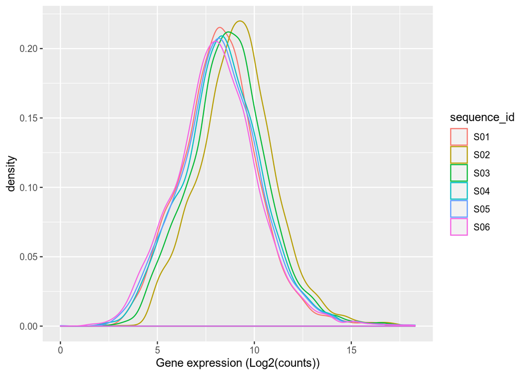

## 3.5 Sample comparison

An important aspect of quality control is comparing the samples. A direct way of comparing the samples is to plot the gene expression levels of one sample against the gene expression levels of another sample.

### 3.5.2 Excercise:

Now you can plot the log2 count values of two sample against each other. Which sample is most similar to sample 1? In what way do the other samples differ from sample 1?

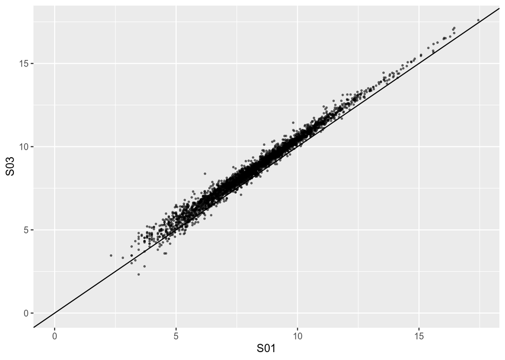

[figure not shown]

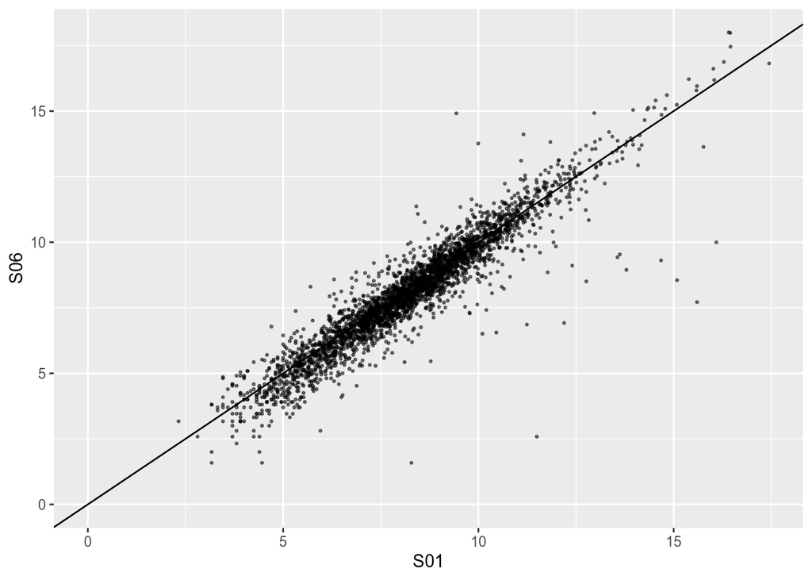

### 3.5.3 Excercise:

It is somewhat challenging to compare all 6 samples with each other. You can use the `ggpairs` function from the `GGally` package to do this automatically.

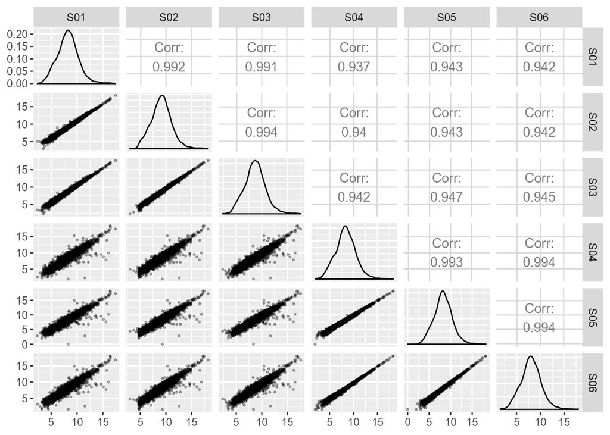

What is your overall impression? Are all samples very similar or do you see differences? Can you give examples of large differences?

## 3.6 MA plots

Although this plot is very informative, it is often more informative and common to compare the gene expression values between samples (or conditions) using an MA plot. In an MA plot you plot the difference in gene expression for each gene on the y-axis. The total expression level is plotted on the x-axis. It was originally developed for microarray data (http://en.wikipedia.org/wiki/MA_plot), but is also widely used for RNA-seq data. It will become clear when you start making such plots:

### 3.6.1 Exercise:

In this MA plot you will compare sample 1 with sample 3:

First calculate the difference in log expression and then plot the difference against total expression:

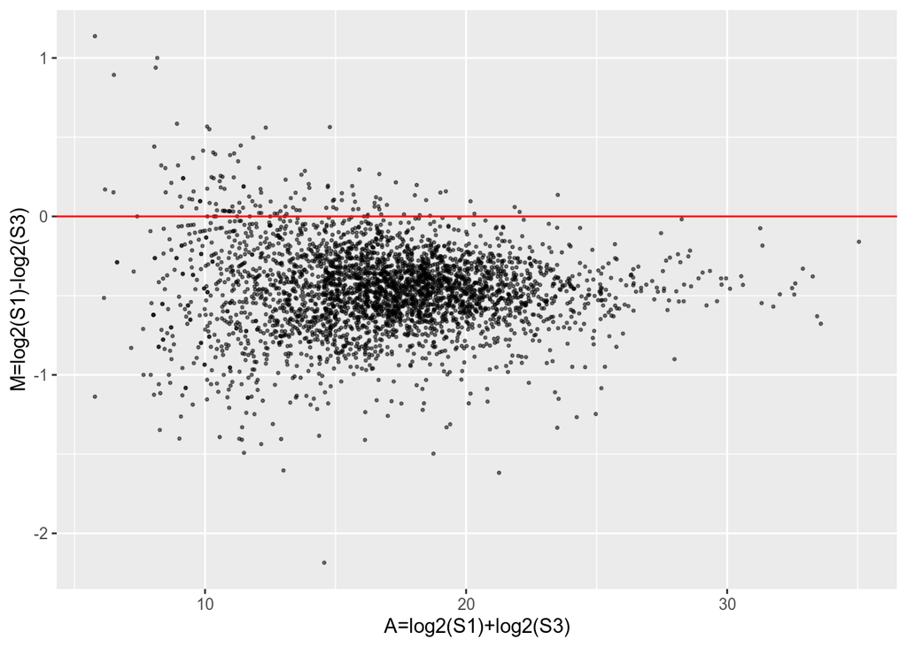

The advantage is that differences from zero in the y-axis directly indicate a difference in log2 fold change. Each dot indicates a gene, and dots on the left side in the graph have a low expression level, and genes on the right side in the graph have a high expression level.

Note that log2 expression values are plotted. Are the samples similar? What can you conclude from this plot?

### 3.6.2 Excercise:

To analyze all 6 samples, it is handy to compare them all with a common reference. This common reference is the based median expression level of each gene across all samples. Use the `df.counts.f` data.frame to first calculate the log2 of the median counts per gene and then calculate M and A per sample.

### 3.6.3 Excercise:

Make a plot comparing every sample to the common reference.

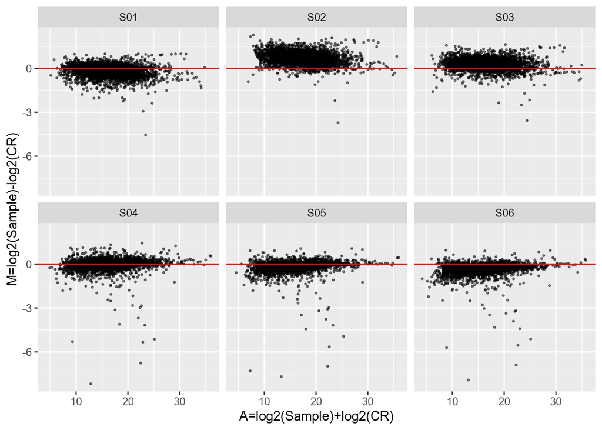

Note that log2 expression values are plotted. Do you see any outliers?

## 3.7 PCA

An important plot for the Quality Control is the Principal Component Analysis plot. This allows you to infer the effect of the different experimental variables. In R, a PCA can be performed using prcomp() function. We already prepared helper functions for performing PCA’s and generating associated plots, you can find them in /home/hugo/Documents/PhD/Shared/1920_SBiP/experiments/20200129_sbip/functions/pca.R.

(Adapted from https://tbradley1013.github.io/2018/02/01/pca-in-a-tidy-verse-framework )

We can use the `f_pca` function to perform the PCA on our data and also extract the most important information. It returns you a nested data.frame.

```
## Observations: 1
## Variables: 4
## $ data         <list> [<tbl_df[6 x 3328]>]
## $ pca          <list> [<2.802365e+01, 1.417579e+01, 4.776911e+00, 4.476511e+0…
## $ pca_aug      <list> [<tbl_df[6 x 3335]>]
## $ pca_loadings <list> [<tbl_df[19962 x 3]>]
```

First look at the amount of variance explained by each component using the `f_pca_var_exp` function.

```
## # A tibble: 6 x 4
##      pc variance  var_exp cum_var_exp
##   <dbl>    <dbl>    <dbl>       <dbl>
## 1     1 7.85e+ 2 7.52e- 1       0.752
## 2     2 2.01e+ 2 1.92e- 1       0.944
## 3     3 2.28e+ 1 2.18e- 2       0.966
## 4     4 2.00e+ 1 1.92e- 2       0.985
## 5     5 1.57e+ 1 1.50e- 2       1
## 6     6 1.04e-28 9.91e-32       1
```

Or in plotted form using `f_pca_plot_var_exp`

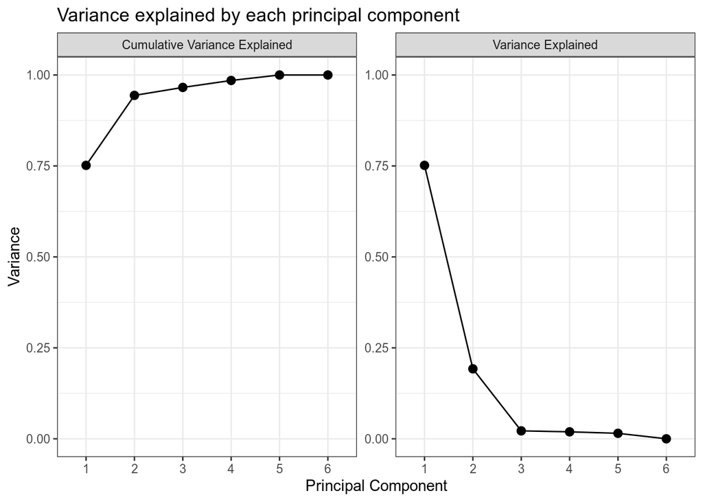

Which components are most relevant for explaining the variance in our dataset?

Let’s inspect where our samples are placed on the first three components.

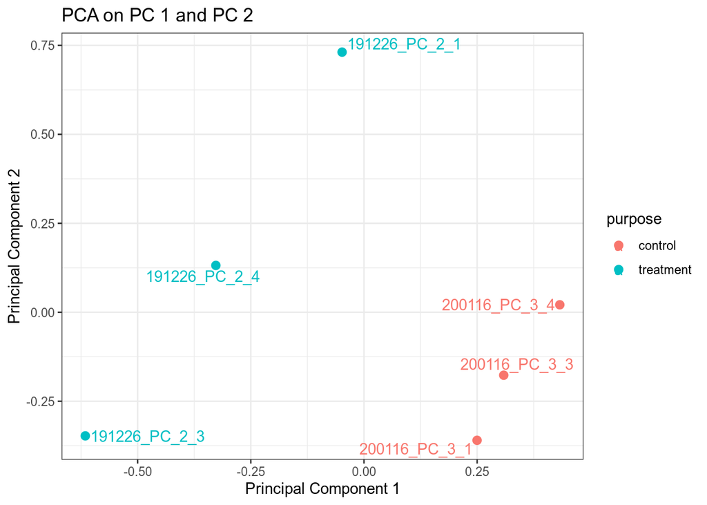

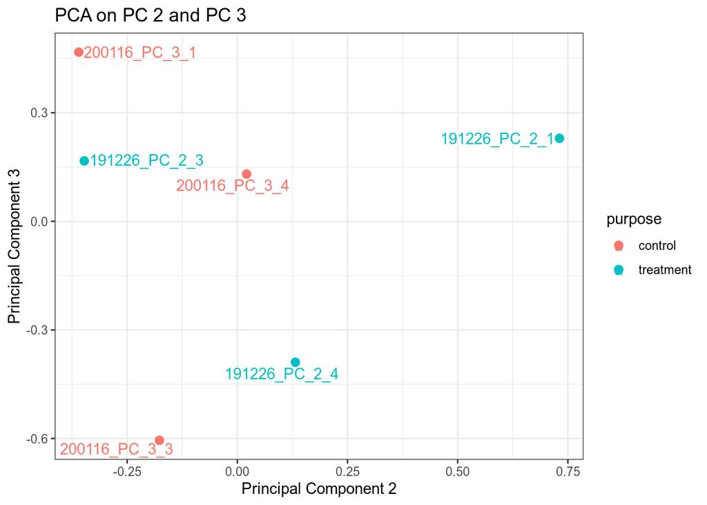

# 4 Normalization

The goal of this exercise is to perform a quality control of the gene expression count data, after normalization. In order to do this you will visualize the data using different types of plots. You will analyze your data using a methodology that is called DESeq, which is described in:

1. https://genomebiology.biomedcentral.com/articles/10.1186/gb-2010-11-10-r106

And in

2. https://www.ncbi.nlm.nih.gov/pmc/articles/PMC4302049/

## 4.1 Size factors

Normalizing count data is one of the steps in the DESeq workflow. It is done to correct for differences in sequencing depth among samples and it is based on the median-of-ratios method. You can find the mathematical formulation in link # 1 provided above. In short, size factors are calculated per sample and give a measure of the median distance all genes of one sample to the geometric mean of each gene across all samples.

### 4.1.1 Exercise:

To calculate the size factors we will follow the next steps ([adapted from this tutorial](https://hbctraining.github.io/DGE_workshop/lessons/02_DGE_count_normalization.html)):

1. Create a pseudo-reference sample: for each gene, calculate the geometric mean of counts. Note: you can also use the [log-average](https://en.wikipedia.org/wiki/Geometric_mean#Relationship_with_logarithms) to calculate this but then you will have to modify the coming steps accordingly.
2. Calculate ratio of each sample to the pseudo-reference: for each sample, calculate the ratio of each gene to the the pseudo-reference. Note: if the pseudo-reference is equal to 0, make this ratio `NA`.
3. Calculate the size factor for each sample: this is done by calculating the median of all ratios per sample. Hint: set the argument `na.rm = T` in the median function.
4. Normalize the count data: for each sample, divide the counts of each gene by the calculated size factor.

Print the calculate size factors for each sample in a table:

| sequence_id | size_factor |
| --- | --- |
| S01 | 0.8449753 |
| S02 | 1.5748351 |
| S03 | 1.1641719 |
| S04 | 0.9563367 |
| S05 | 0.8856490 |
| S06 | 0.7758809 |

## 4.2 Visualizing the effect of normalization

Remake the plots you created in sections 2.1 and 2.4 using the normalized data

### 4.2.1 Exercise:

Plot the total number of counts per sample:

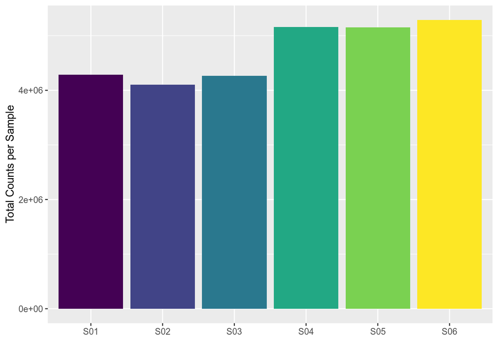

How many reads do you (approximately) have from each sample? Are the samples different? Do you see outliers? Has the normalization worked?

### 4.2.2 Exercise:

Make a boxplot to visualize the distribution of normalized counts, for every sample:

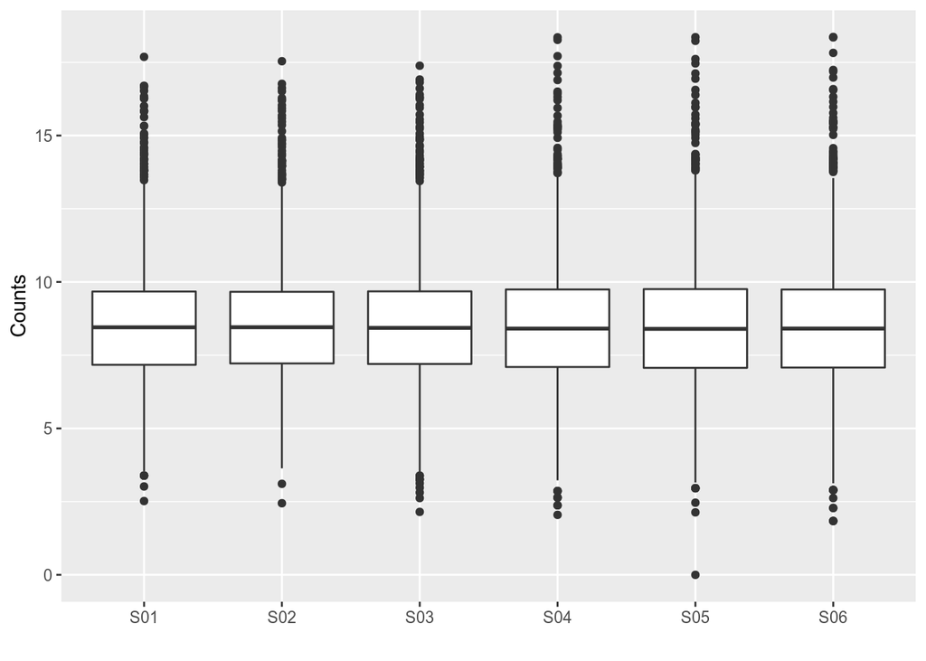

Are the samples similar or different? Do you see outliers? Can you conclude that the normalization worked?

### 4.2.3 Exercise:

You can also make density plots to visualize the distribution of normalized counts, for every sample:

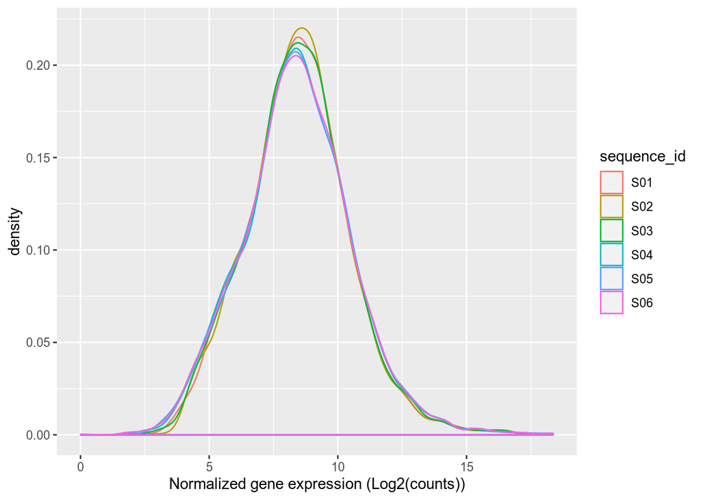

Are the samples similar or different? Do you see outliers? Can you conclude that the normalization worked?

## 4.3 PCA

Repeat the PCA done section 2.7 using the normalized data.

### 4.3.1 Exercise:

Make a plot showing the explained variance for each component

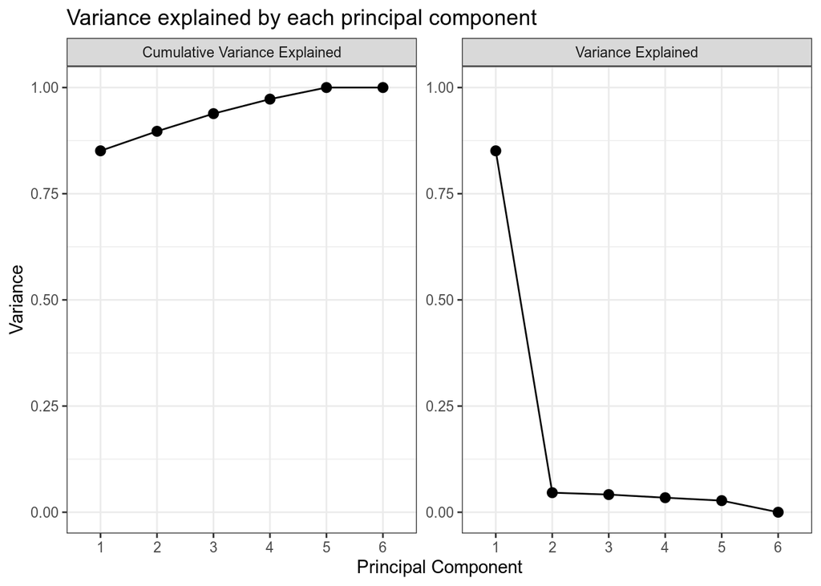

### 4.3.2 Exercise:

Make a plot showing where out samples are place on the fist 3 components

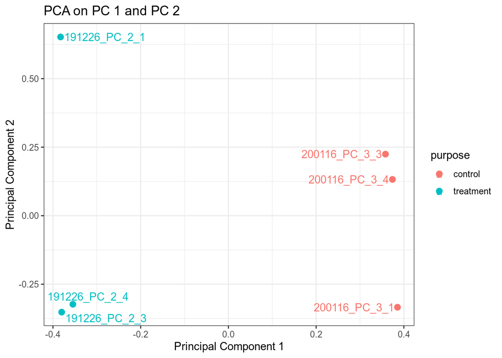

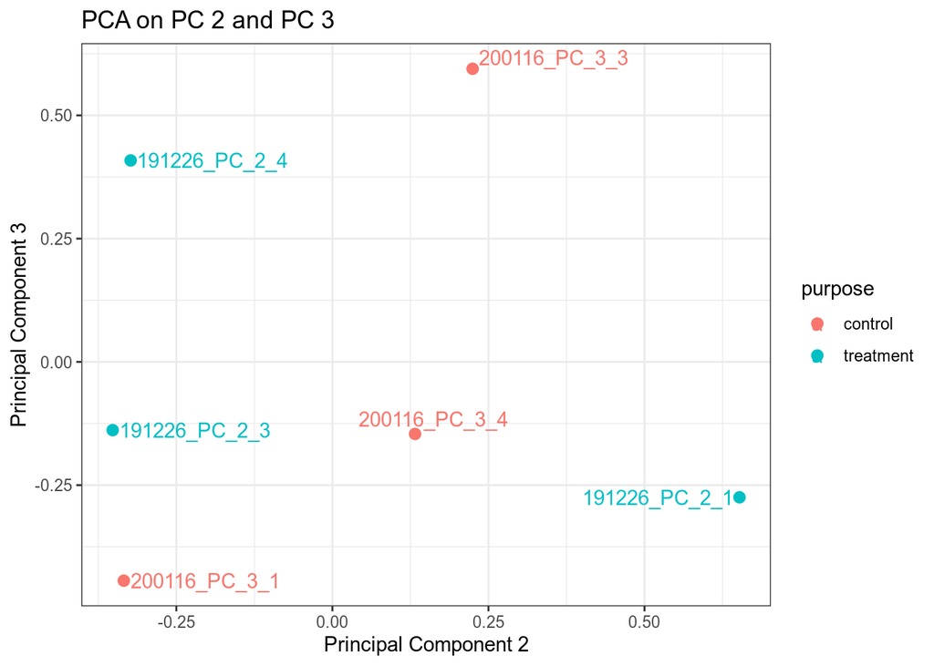

Does this look different from the PCA with pre-normalized data? In what way?

### 4.3.3 Exercise:

We will now investigate which genes are contributing most to the difference between the samples along the first PC axis (PC1).

Most down-regulated genes of PC 1:

```
## # A tibble: 10 x 2
##    gene    loading
##    <chr>     <dbl>
##  1 sll1552  -0.227
##  2 sll0654  -0.201
##  3 sll0720  -0.180
##  4 nucH     -0.165
##  5 pstS     -0.152
##  6 pstC     -0.132
##  7 sphX     -0.130
##  8 pstA     -0.120
##  9 sll0594  -0.107
## 10 pstB     -0.105
```

Most up-regulated genes of PC 1:

```
## # A tibble: 10 x 2
##    gene      loading
##    <chr>       <dbl>
##  1 slr1634    0.137
##  2 amiC       0.0995
##  3 sll1863    0.0794
##  4 slr0376    0.0750
##  5 glnH/glnP  0.0667
##  6 sll7064    0.0589
##  7 slr5037    0.0550
##  8 sll7065    0.0543
##  9 sll1862    0.0540
## 10 petJ       0.0534
```

Another useful tool is to plot the expression levels in a heatmap.

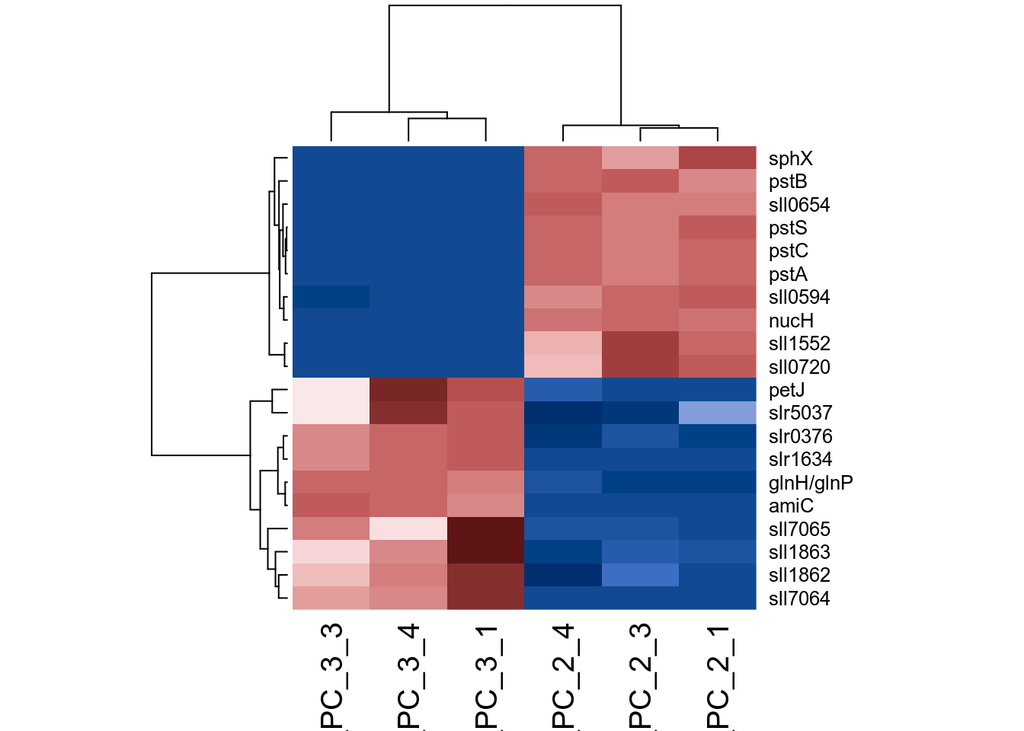

# 5 Differential Expression

The goal of this exercise is to find differentially expressed genes.

First, recall the experimental design. What are our experimental groups?

| sample_id | sequence_id | phosphate_mM | purpose |
| --- | --- | --- | --- |
| 191226_PC_2_1 | S01 | 0.0115 | treatment |
| 191226_PC_2_3 | S02 | 0.0115 | treatment |
| 191226_PC_2_4 | S03 | 0.0115 | treatment |
| 200116_PC_3_1 | S04 | 0.2300 | control |
| 200116_PC_3_3 | S05 | 0.2300 | control |
| 200116_PC_3_4 | S06 | 0.2300 | control |

We are analyzing our data using the DESeq methodology. Instead of reinventing the wheel we will use the `DESeq2` package. You can find more information about the theoretical background of the package in the papers provided above.

## 5.1 Preparing the data for DESeq2

DESeq2 needs as inputs, at least, 3 objects:

- countData: a matrix containing genes in rows and samples in columns. Gene names should be set as the row names of the matrix.
- colData: a data.frame with two columns, one containing the sample names and the other one containing the experimental conditions (in our case, control and treatment).
- design: a formula indicating the name of the column in the colData object that contains the experimental conditions.

### 5.1.1 Exercise:

Create a data.frame containing the (filtered) counts data and the design data. It should look like this:

```
## # A tibble: 19,962 x 12
##    gene  counts sequence_id counts_log2 sample_id multicultivator channel strain
##    <chr>  <dbl> <chr>             <dbl> <chr>               <dbl>   <dbl> <chr>
##  1 AT103     20 S01                4.39 191226_P…               0       1 WT
##  2 ESI3      92 S01                6.54 191226_P…               0       1 WT
##  3 ETR1     142 S01                7.16 191226_P…               0       1 WT
##  4 Era      305 S01                8.26 191226_P…               0       1 WT
##  5 HAGH1    163 S01                7.36 191226_P…               0       1 WT
##  6 IAP75   3169 S01               11.6  191226_P…               0       1 WT
##  7 ICFG     800 S01                9.65 191226_P…               0       1 WT
##  8 Sac1     282 S01                8.14 191226_P…               0       1 WT
##  9 aat       37 S01                5.25 191226_P…               0       1 WT
## 10 abfB     136 S01                7.10 191226_P…               0       1 WT
## # … with 19,952 more rows, and 4 more variables: sample_time <dttm>,
## #   phosphate_mM <dbl>, purpose <chr>, dataset <chr>
```

### 5.1.2 Exercise:

Create the object for countData. Transform the df.diff to wide format, set the genes as row names and convert to matrix. It should look like this:

```
##        S04  S05  S06  S01  S02  S03
## AT103   26   28   18   20   34   30
## ESI3    84   98   77   92  200  123
## ETR1   120  141   98  142  242  209
## Era    380  244  260  305  651  375
## HAGH1  196  139  121  163  313  248
## IAP75 3181 3046 2703 3169 5090 4282
```

### 5.1.3 Excercise:

Create the object for colData. It should look like this:

```
## # A tibble: 6 x 2
##   sequence_id purpose
##   <fct>       <fct>
## 1 S04         control
## 2 S05         control
## 3 S06         control
## 4 S01         treatment
## 5 S02         treatment
## 6 S03         treatment
```

### 5.1.4 Exercise:

Create the DESeq2 object and estimate size factors to apply counts normalization

## 5.2 Counts normalization

The previous function call creates a DESeq2 object which, among many other things, contains the normalized counts and the estimated size factors. These factors should be equal to the ones we calculated previously.

### 5.2.1 Exercise:

Check if the previous statement is true.

| sequence_id | size_factor |
| --- | --- |
| S01 | 0.8449753 |
| S02 | 1.5748351 |
| S03 | 1.1641719 |
| S04 | 0.9563367 |
| S05 | 0.8856490 |
| S06 | 0.7758809 |

You can access the normalized counts from the DESeq object by calling the `counts` function with `normalized = TRUE`. This is how the normalized data looks like:

```
##              S04        S05        S06        S01        S02        S03
## AT103   27.18708   31.61523   23.19944   23.66933   21.58956   25.76939
## ESI3    87.83518  110.65331   99.24203  108.87892  126.99742  105.65450
## ETR1   125.47882  159.20528  126.30804  168.05225  153.66688  179.52675
## Era    397.34961  275.50417  335.10296  360.95730  413.37662  322.11738
## HAGH1  204.94874  156.94705  155.95176  192.90505  198.75097  213.02696
## IAP75 3326.23447 3439.28563 3483.78197 3750.40554 3232.08446 3678.15098
```

## 5.3 Dispersion estimation

In RNA-seq count data there is a dependency between the variance and the mean that is addressed in the statistical procedures that are used for differential gene expression analysis. This plot visualizes the (overdispersed) mean-variance dependency in your normalized data:

Computing mean and variance:

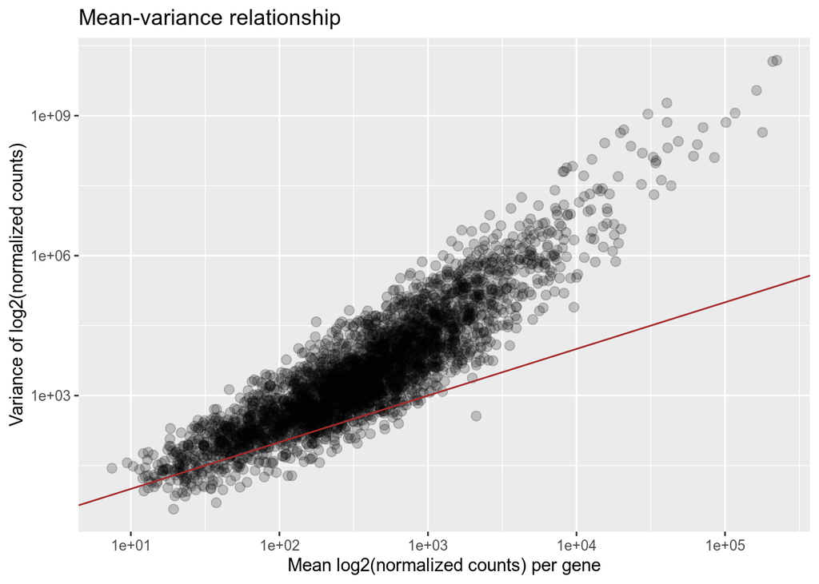

DESeq2 resolves this issue using regression and shrinkage:

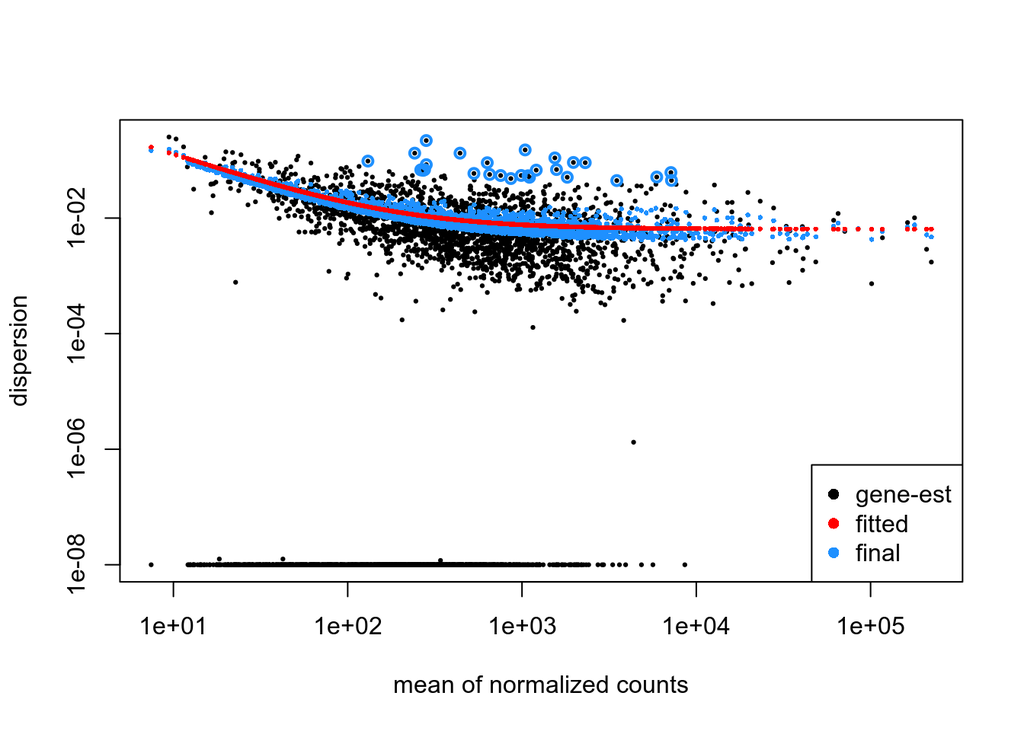

## 5.4 Differential expression

In order to extract the results of the DESeq analysis, we need to call the `results()` function on the previously created DESeq object. The following code extracts into a data.frame the log fold change, the p-values and adjusted p-values for differential expression.

| gene | baseMean | log2FoldChange | lfcSE | stat | pvalue | padj |
| --- | --- | --- | --- | --- | --- | --- |
| AT103 | 25.50501 | -0.1916194 | 0.2986252 | -0.6418231 | 0.5209880 | 0.6338481 |
| ESI3 | 106.54356 | 0.1992797 | 0.1785884 | 1.1156377 | 0.2645773 | 0.3760105 |
| ETR1 | 152.03967 | 0.2734443 | 0.1596078 | 1.7129936 | 0.0867137 | 0.1525630 |
| Era | 350.73467 | 0.1199726 | 0.1430446 | 0.8386645 | 0.4016576 | 0.5194266 |
| HAGH1 | 187.08842 | 0.2142938 | 0.1507856 | 1.4210019 | 0.1553162 | 0.2458311 |
| IAP75 | 3484.99051 | 0.0554742 | 0.0897230 | 0.6182854 | 0.5363872 | 0.6484594 |

The results can be plotted in an MA plot:

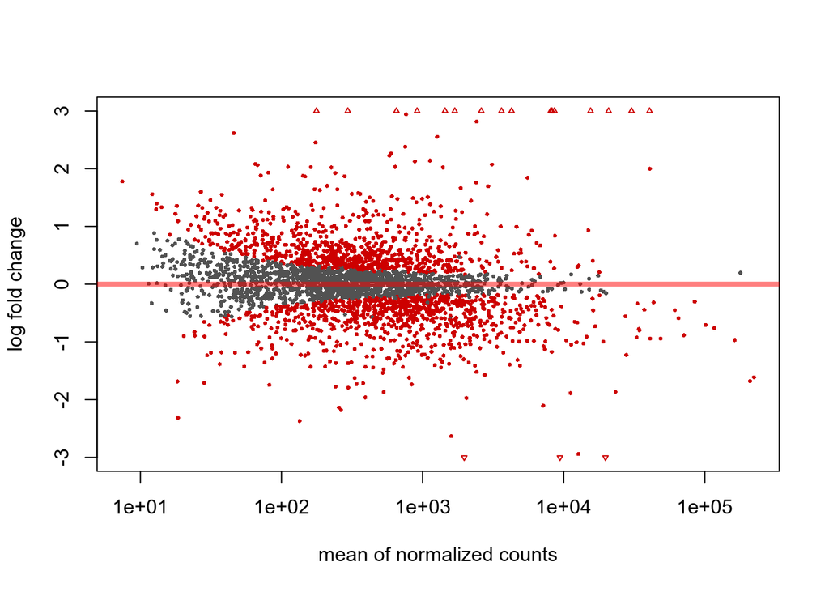

…and you can plot the expression values of for instance the 10 most differentially expressed genes:

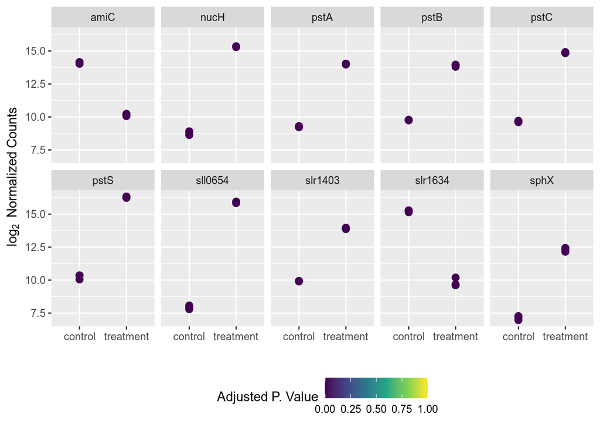

### 5.4.1 Exercise:

How many genes have an adj p-value < 0.01?

Answer: 1207.

### 5.4.2 Excercise:

Draw an histogram of the p-values and the adjusted p-values

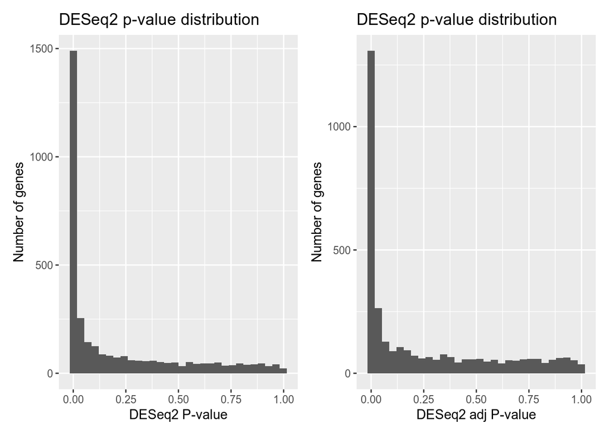

### 5.4.3 Excercise:

Create a volcano plot.

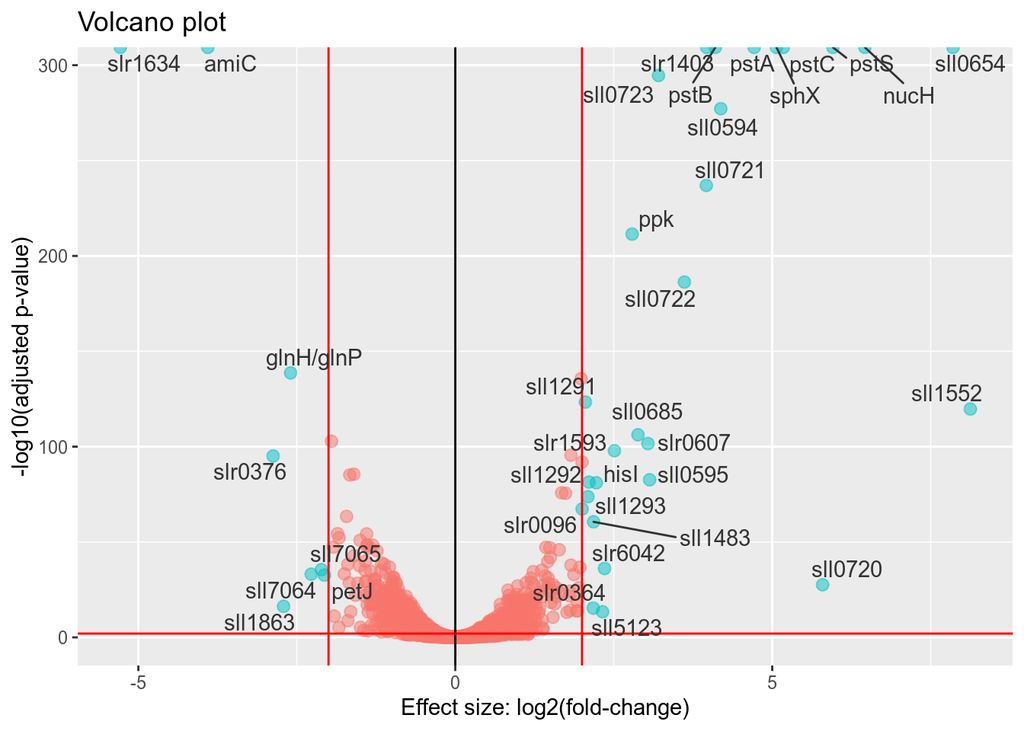

### 5.4.4 Exercise:

Print a table with all the genes with adj p-value < 0.01 and log fold change > 2.

| gene | baseMean | log2FoldChange | lfcSE | stat | pvalue | padj |
| --- | --- | --- | --- | --- | --- | --- |
| slr1634 | 19777.15878 | -5.285370 | 0.1254559 | -42.100258 | 0 | 0 |
| amiC | 9403.41756 | -3.904825 | 0.0883051 | -44.201980 | 0 | 0 |
| slr1403 | 8251.46024 | 3.965997 | 0.0842125 | 47.062210 | 0 | 0 |
| pstB | 8098.19056 | 4.102974 | 0.0883609 | 46.396667 | 0 | 0 |
| pstA | 8596.19340 | 4.714814 | 0.0867471 | 54.275118 | 0 | 0 |
| sphX | 2605.54493 | 5.067331 | 0.1227929 | 40.961615 | 0 | 0 |
| pstC | 15500.87089 | 5.175105 | 0.0851707 | 60.692507 | 0 | 0 |
| pstS | 40614.10586 | 5.957979 | 0.0978243 | 60.855515 | 0 | 0 |
| nucH | 20802.56889 | 6.461794 | 0.0949813 | 67.846384 | 0 | 0 |
| sll0654 | 30245.13918 | 7.852965 | 0.1019336 | 76.532346 | 0 | 0 |
| sll0723 | 3622.55188 | 3.206341 | 0.0868611 | 36.884368 | 0 | 0 |
| sll0594 | 1442.15122 | 4.188438 | 0.1163392 | 35.779311 | 0 | 0 |
| sll0721 | 4270.71116 | 3.960210 | 0.1195234 | 33.088664 | 0 | 0 |
| ppk | 2413.24297 | 2.789296 | 0.0891573 | 31.260566 | 0 | 0 |
| sll0722 | 914.01220 | 3.615031 | 0.1224730 | 29.350124 | 0 | 0 |
| glnH/glnP | 1595.09671 | -2.598133 | 0.1024505 | -25.343683 | 0 | 0 |
| sll1291 | 3101.15950 | 2.053192 | 0.0858406 | 23.912676 | 0 | 0 |
| sll1552 | 1690.38691 | 8.125828 | 0.2621408 | 23.555387 | 0 | 0 |
| sll0685 | 763.61650 | 2.882493 | 0.1294801 | 22.196748 | 0 | 0 |
| slr0607 | 652.42191 | 3.039183 | 0.1394017 | 21.710851 | 0 | 0 |
| slr1593 | 1266.53182 | 2.510339 | 0.1176945 | 21.305953 | 0 | 0 |
| slr0376 | 12707.49112 | -2.874160 | 0.1368229 | -21.004237 | 0 | 0 |
| sll0595 | 295.19046 | 3.065807 | 0.1547884 | 19.584811 | 0 | 0 |
| sll1292 | 1127.69864 | 2.108668 | 0.1083922 | 19.438854 | 0 | 0 |
| hisI | 596.84033 | 2.225320 | 0.1145008 | 19.398010 | 0 | 0 |
| sll1293 | 881.49736 | 2.092038 | 0.1129283 | 18.506943 | 0 | 0 |
| slr0096 | 640.03443 | 2.000738 | 0.1129830 | 17.684886 | 0 | 0 |
| sll1483 | 582.45118 | 2.181477 | 0.1297207 | 16.787484 | 0 | 0 |
| slr6042 | 174.36264 | 2.353801 | 0.1797602 | 12.985387 | 0 | 0 |
| sll7065 | 264.30013 | -2.112276 | 0.1636629 | -12.876342 | 0 | 0 |
| sll7064 | 134.45549 | -2.272804 | 0.1815262 | -12.442298 | 0 | 0 |
| petJ | 255.62540 | -2.064304 | 0.1668064 | -12.348665 | 0 | 0 |
| sll0720 | 176.92265 | 5.795054 | 0.3339371 | 11.349673 | 0 | 0 |
| sll1863 | 1971.77673 | -2.709240 | 0.3116859 | -8.694742 | 0 | 0 |
| slr0364 | 754.24096 | 2.176862 | 0.2574683 | 8.446758 | 0 | 0 |
| sll5123 | 45.90136 | 2.323667 | 0.2846438 | 7.893656 | 0 | 0 |

## 5.5 Export

DEseq data was exported to ./data/processed/transcriptomics_deseq/20200305_transcriptomics_deseq.csv